# single cell 10x single-cell analysis - part6

UC Davis Bioinformatics Core

# 0. Setup

Load the final Seurat object, load libraries (also see additional required packages for each example)

# 1. DE With Single Cell Data Using Limma

For differential expression using models more complex than those allowed by FindAllMarkers(), data from Seurat may be used in limma (https://www.bioconductor.org/packages/devel/bioc/vignettes/limma/inst/doc/usersguide.pdf)

We illustrate by comparing sample 1 to sample 2 within cluster 0:

```r
library(limma)
cluster0 <- SubsetData(experiment.aggregate, ident.use = 0)
expr <- cluster0@data

# Filter out genes that are 0 for every cell in this cluster
bad <- which(rowSums(expr) == 0)
expr <- expr[-bad,]

mm <- model.matrix(~0 + orig.ident, data = cluster0@meta.data)
fit <- lmFit(expr, mm)
head(coef(fit)) # means in each sample for each gene
```

```
##         orig.identsample1 orig.identsample2 orig.identsample3
## Mrpl15        0.308056932       0.233220268       0.365672775
## Lypla1        0.296334196       0.264225566       0.325912665
## Tcea1         0.269425949       0.257152221       0.302355174
## Rgs20         0.006704523       0.007281172       0.011679030
## Atp6v1h       0.322142900       0.267904522       0.387039804
## Oprk1         0.001741248       0.001999901       0.001942202
```

```r
contr <- makeContrasts(orig.identsample2 - orig.identsample1, levels = colnames(coef(fit)))
tmp <- contrasts.fit(fit, contrasts = contr)
tmp <- eBayes(tmp)
topTable(tmp, sort.by = "P", n = 20) # top 20 DE genes
```

```
##                    logFC   AveExpr         t      P.Value    adj.P.Val        B
## Rps29          0.2323318 2.7382343  9.575604 2.176701e-21 2.482092e-17 37.68826
## Malat1         0.3985648 3.9071461  9.212669 6.141584e-20 3.501624e-16 34.40453
## 9130204L05Rik -0.2656994 0.4286414 -8.828500 1.851382e-18 7.037102e-15 31.05874
## Xist          -0.3786369 0.9744056 -8.533504 2.311746e-17 6.590210e-14 28.58098
## Snrpn         -0.2433459 2.2076308 -8.203731 3.539098e-16 8.071266e-13 25.90570
## Rpl41          0.1356469 3.6981405  7.849716 5.926983e-15 1.126423e-11 23.14557
## Ndn           -0.2352288 0.8125448 -7.606332 3.848212e-14 6.268737e-11 21.31550
## Fez1          -0.2333460 2.1579122 -7.483866 9.662257e-14 1.377234e-10 20.41555
## Calcb         -0.2422010 2.5339466 -7.342590 2.746832e-13 3.480236e-10 19.39478
## Oaz2          -0.2123888 1.0070645 -7.159490 1.035082e-12 1.180304e-09 18.09966
## Aldoa         -0.2216651 2.3634321 -6.768518 1.584710e-11 1.642768e-08 15.43981
## Zwint         -0.1978167 1.9348312 -6.745993 1.846446e-11 1.754585e-08 15.29097
## Pmm1          -0.2083454 1.3686732 -6.515075 8.611401e-11 7.171283e-08 13.79276
## Eif4a2        -0.1755853 2.3295583 -6.511694 8.804522e-11 7.171283e-08 13.77119
## Slc25a4       -0.1514549 3.0856518 -6.434632 1.455325e-10 1.106338e-07 13.28272
## Tuba1a        -0.1879961 3.1054677 -6.321886 3.005653e-10 2.142092e-07 12.57821
## Tuba1b        -0.2095709 1.7806285 -6.285291 3.793722e-10 2.394600e-07 12.35213
## Hspa8         -0.1943548 2.4676129 -6.280769 3.904116e-10 2.394600e-07 12.32429
## Ubb           -0.2208200 3.8414680 -6.277339 3.989949e-10 2.394600e-07 12.30318
## Rpl38          0.1756736 2.2450175  6.243086 4.954721e-10 2.824934e-07 12.09299
```

- logFC: log2 fold change (sample2/sample1)
- AveExpr: Average expression, in log2 counts per million, across all cells included in analysis (i.e. those in cluster 0)
- t: t-statistic, i.e. logFC divided by its standard error
- P.Value: Raw p-value from test that logFC differs from 0
- adj.P.Val: Benjamini-Hochberg false discovery rate adjusted p-value

The limma vignette linked above gives more detail on model specification.

# 2. Gene Ontology (GO) Enrichment of Genes Expressed in a Cluster

```r
library(topGO)
```

```r
# install org.Mm.eg.db if not already installed (for mouse only)
# install.packages("org.Mm.eg.db")
cluster0 <- SubsetData(experiment.aggregate, ident.use = 0)
expr <- cluster0@data
# Select genes that are expressed > 0 in at least 75% of cells (somewhat arbitrary definition)
n.gt.0 <- apply(expr, 1, function(x)length(which(x > 0)))
expressed.genes <- rownames(expr)[which(n.gt.0/ncol(expr) >= 0.75)]
all.genes <- rownames(expr)

# define geneList as 1 if gene is in expressed.genes, 0 otherwise
geneList <- ifelse(all.genes %in% expressed.genes, 1, 0)
names(geneList) <- all.genes

# Create topGOdata object
    GOdata <- new("topGOdata",
        ontology = "BP", # use biological process ontology
        allGenes = geneList,
        geneSelectionFun = function(x)(x == 1),
              annot = annFUN.org, mapping = "org.Mm.eg.db", ID = "symbol")
```

```
##
## Building most specific GOs .....
```

```
##  ( 9613 GO terms found. )
```

```
##
## Build GO DAG topology ..........
```

```
##  ( 13585 GO terms and 32452 relations. )
```

```
##
## Annotating nodes ...............
```

```
##  ( 10752 genes annotated to the GO terms. )
```

```r
# Test for enrichment using Fisher's Exact Test
    resultFisher <- runTest(GOdata, algorithm = "elim", statistic = "fisher")
```

```
##
##           -- Elim Algorithm --
##
##       the algorithm is scoring 5401 nontrivial nodes
##       parameters:
##           test statistic: fisher
##           cutOff: 0.01
```

```
##
##   Level 19:  2 nodes to be scored    (0 eliminated genes)
```

```
##
##   Level 18:  4 nodes to be scored    (0 eliminated genes)
```

```
##
##   Level 17:  3 nodes to be scored    (8 eliminated genes)
```

```
##
##   Level 16:  20 nodes to be scored   (8 eliminated genes)
```

```
##
##   Level 15:  47 nodes to be scored   (10 eliminated genes)
```

```
##
##   Level 14:  95 nodes to be scored   (55 eliminated genes)
```

```
##
##   Level 13:  200 nodes to be scored  (91 eliminated genes)
```

```
##
##   Level 12:  315 nodes to be scored  (580 eliminated genes)
```

```
##
##   Level 11:  483 nodes to be scored  (645 eliminated genes)
```

```
##
##   Level 10:  584 nodes to be scored  (1036 eliminated genes)
```

```
##
##   Level 9:   712 nodes to be scored  (1417 eliminated genes)
```

```
##
##   Level 8:   725 nodes to be scored  (1628 eliminated genes)
```

```
##
##   Level 7:   794 nodes to be scored  (2010 eliminated genes)
```

```
##
##   Level 6:   670 nodes to be scored  (2314 eliminated genes)
```

```
##
##   Level 5:   437 nodes to be scored  (2862 eliminated genes)
```

```
##
##   Level 4:   225 nodes to be scored  (3445 eliminated genes)
```

```
##
##   Level 3:   64 nodes to be scored   (4692 eliminated genes)
```

```
##
##   Level 2:   20 nodes to be scored   (4818 eliminated genes)
```

```
##
##   Level 1:   1 nodes to be scored    (4818 eliminated genes)
```

```r
    GenTable(GOdata, Fisher = resultFisher, topNodes = 20, numChar = 60)
```

```
##         GO.ID                                                            Term Annotated Significant Expected  Fisher
## 1  GO:0006412                                                     translation       484          97    29.44 4.4e-18
## 2  GO:0015986                          ATP synthesis coupled proton transport        19          14     1.16 7.3e-14
## 3  GO:0000028                                ribosomal small subunit assembly        17          12     1.03 1.1e-11
## 4  GO:0006123        mitochondrial electron transport, cytochrome c to oxygen         8           7     0.49 2.3e-08
## 5  GO:0002181                                         cytoplasmic translation        47          16     2.86 7.4e-08
## 6  GO:0015991                         ATP hydrolysis coupled proton transport        18           8     1.09 4.6e-06
## 7  GO:0006120            mitochondrial electron transport, NADH to ubiquinone        13           6     0.79 5.9e-05
## 8  GO:0050821                                           protein stabilization       120          19     7.30 0.00011
## 9  GO:0034314                        Arp2/3 complex-mediated actin nucleation        27           8     1.64 0.00014
## 10 GO:0006122     mitochondrial electron transport, ubiquinol to cytochrome c        10           5     0.61 0.00016
## 11 GO:0046034                                           ATP metabolic process       156          47     9.49 0.00018
## 12 GO:1902255 positive regulation of intrinsic apoptotic signaling pathway...         6           4     0.36 0.00018
## 13 GO:0061077                              chaperone-mediated protein folding        51          11     3.10 0.00020
## 14 GO:0010592                   positive regulation of lamellipodium assembly        16           6     0.97 0.00023
## 15 GO:0006364                                                 rRNA processing       162          24     9.85 0.00026
## 16 GO:0045730                                               respiratory burst        11           5     0.67 0.00028
## 17 GO:0006900                                                membrane budding        47          10     2.86 0.00043
## 18 GO:0047497                       mitochondrion transport along microtubule        12           5     0.73 0.00045
## 19 GO:0006810                                                       transport      2768         254   168.37 0.00061
## 20 GO:0055114                                     oxidation-reduction process       583          69    35.46 0.00062
```

- Annotated: number of genes (out of all.genes) that are annotated with that GO term
- Significant: number of genes that are annotated with that GO term and meet our criteria for “expressed”
- Expected: Under random chance, number of genes that would be expected to be annotated with that GO term and meeting our criteria for “expressed”
- Fisher: (Raw) p-value from Fisher’s Exact Test

# 3. Weighted Gene Co-Expression Network Analysis (WGCNA)

WGCNA identifies groups of genes (“modules”) with correlated expression. WARNING: TAKES A LONG TIME TO RUN

```r
library(WGCNA)
```

```r
options(stringsAsFactors = F)
datExpr <- t(experiment.aggregate@data)[,experiment.aggregate@var.genes]  # only use var.genes in analysis

net <- blockwiseModules(datExpr, power = 10,
  corType = "bicor", # use robust correlation
    networkType = "signed", minModuleSize = 10,
    reassignThreshold = 0, mergeCutHeight = 0.15,
    numericLabels = F, pamRespectsDendro = FALSE,
    saveTOMs = TRUE,
    saveTOMFileBase = "TOM",
    verbose = 3)
```

```
##  Calculating module eigengenes block-wise from all genes
##    Flagging genes and samples with too many missing values...
##     ..step 1
##  ..Working on block 1 .
##     TOM calculation: adjacency..
##     ..will not use multithreading.
##      Fraction of slow calculations: 0.000000
##     ..connectivity..
##     ..matrix multiplication (system BLAS)..
##     ..normalization..
##     ..done.
##    ..saving TOM for block 1 into file TOM-block.1.RData
##  ....clustering..
##  ....detecting modules..
##  ....calculating module eigengenes..
##  ....checking kME in modules..
```

```
##      ..removing 1 genes from module 5 because their KME is too low.
```

```
##      ..removing 1 genes from module 7 because their KME is too low.
```

```
##      ..removing 4 genes from module 8 because their KME is too low.
```

```
##  ..merging modules that are too close..
##      mergeCloseModules: Merging modules whose distance is less than 0.15
##        Calculating new MEs...
```

```r
table(net$colors)
```

```
##
##      blue     brown     green      grey turquoise    yellow
##        39        26        17       974        46        21
```

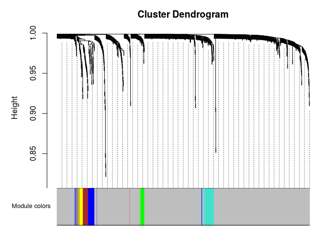

```r
# Convert labels to colors for plotting
mergedColors = net$colors
# Plot the dendrogram and the module colors underneath
plotDendroAndColors(net$dendrograms[[1]], mergedColors[net$blockGenes[[1]]],
"Module colors",
dendroLabels = FALSE, hang = 0.03,
addGuide = TRUE, guideHang = 0.05)
```

Genes in grey module are unclustered.

What genes are in the “blue” module?

```r
colnames(datExpr)[net$colors == "blue"]
```

[output not shown]

Each cluster is represented by a summary “eigengene”. Plot eigengenes for each non-grey module by clusters from Seurat:

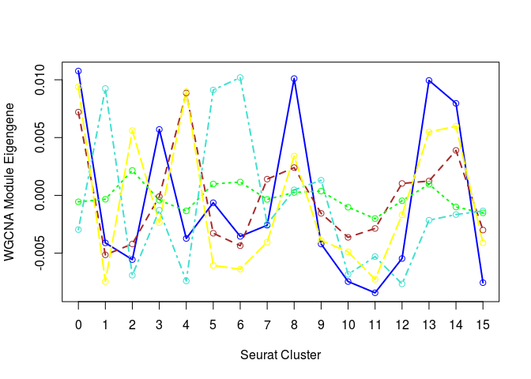

```r
f <- function(module){
  eigengene <- unlist(net$MEs[paste0("ME", module)])
  means <- tapply(eigengene, experiment.aggregate@ident, mean, na.rm = T)
  return(means)
}
modules <- c("blue", "brown", "green", "turquoise", "yellow")
plotdat <- sapply(modules, f)
matplot(plotdat, col = modules, type = "l", lwd = 2, xaxt = "n", xlab = "Seurat Cluster",
        ylab = "WGCNA Module Eigengene")
axis(1, at = 1:16, labels = 0:15)
matpoints(plotdat, col = modules, pch = 21)
```